# AYUDANTÍA 1: Dependencia espacial

Joseba Iribarren josebairibarren@gmail.com

2025-03-14

# AYUDANTÍA 1: Dependencia espacial

En esta ayudantía veremos como opera los patrones espaciales (atracción, repulsión e “indiferencia”), interpretando cada uno mediante el K-Ripley.

Además de como podemos visualizar la primera ley de la geografía, o ley de Tobler:

**“Todas las cosas están relacionadas entre sí, pero las cosas más próximas en el espacio tienen una relación mayor que las distantes.”** (Waldo Tobler)

### 0) Paquetes y working directory

```r
require(pacman)
pacman::p_load(tidyverse, # para manejo de datos
               plotly, #mapa interactivo para ggplot
               gridExtra, # para unir graficos
               sf, # para trabajar con datos vectoriales
               terra, # para trabajar con datos raster
               leaflet, # para hacer mapas dinamicos
               spatstat, # calculo K de Ripley
               spdep, # autocorrelograma
               ncf, # spline correlation
               geostats, # semivarigrama
               gstat, # mapa semivarigrama y semivarigrama direccional
               latex2exp) #LaTeX

setwd(dirname(rstudioapi::getActiveDocumentContext()$path)) ##Cambiar de ser necesario
```

### 1) Cargar capas

```r
# Ver las capas de mi archivo geopackage
st_layers("datosAyu1.gpkg")
```

```
## Driver: GPKG
## Available layers:
##             layer_name geometry_type features fields crs_name
## 1 Ayud1_pEquidistantes         Point      302      0   WGS 84
## 2    Ayud1_pAleatorios         Point      300      0   WGS 84
## 3     Ayud1_pAgrupados         Point      300      0   WGS 84
## 4              losRios Multi Polygon        1      2   WGS 84
```

```r
# Capas vectoriales ("puntos de muestreo")
agrupados <- st_read("datosAyu1.gpkg", layer = "Ayud1_pAgrupados", quiet=TRUE) # `quiet` suprime imprimir la def de la capa leida
aleatorios <- st_read("datosAyu1.gpkg", layer = "Ayud1_pAleatorios", quiet=TRUE)
uniforme <- st_read("datosAyu1.gpkg", layer = "Ayud1_pEquidistantes", quiet=TRUE)
losRios <- st_read("datosAyu1.gpkg", layer = "losRios", quiet=TRUE)

# Capa raster (% arcilla a 5-15cm)
arcilla <- rast('Arcilla5_15LosRios.tif')

# Galleguillos, M., Dinamarca, D., Seguel, O., & Faundez, C. (2022). CLSoilMaps: A national soil gridded product for Chile [Data set]. En Earth Science System Data (Versión V1). Zenodo. https://doi.org/10.5281/zenodo.7464210
```

### 2) Visualizar capas

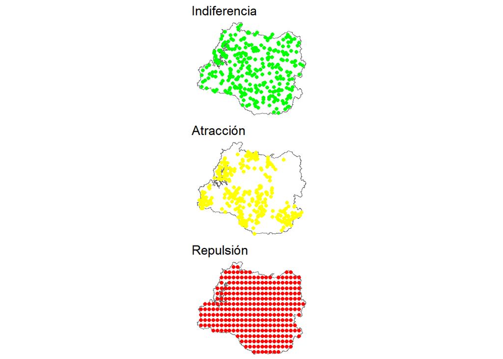

```r
map1 <- ggplot() +
  geom_sf(data = losRios, fill = 'white') +
  geom_sf(data = aleatorios, color = 'green') +
  ggtitle('Indiferencia') +
  theme_void()

map2 <- ggplot() +
  geom_sf(data = losRios, fill = 'white') +
  geom_sf(data = agrupados, color = 'yellow') +
  ggtitle('Atracción') +
  theme_void()

map3 <- ggplot() +
  geom_sf(data = losRios, fill = 'white') +
  geom_sf(data = uniforme, color = 'red') +
  ggtitle('Repulsión') +
  theme_void()

grid.arrange(map1, map2, map3, ncol = 1)
```

[Link: Ejemplos en la Naturaleza](https://imgur.com/a/gaMxt38)

Cuando vemos patrones espaciales en la naturaleza siempre tenemos que preguntarnos:

*¿A que escala ocurre este patron?*  
*¿A otra escala esto cambia?*

Hagamos zoom en el siguiente mapa para descubrirlo

```r
# Mapa interactivo 1
ggplotly(map2)
```

[interactive chart not shown]

```r
# Mapa interactivo 2
leaflet() %>%
  addTiles() %>%
  addPolygons(data = losRios) %>%
  addCircleMarkers(data = agrupados, color = 'yellow', radius = 1, opacity = 1)
```

[interactive chart not shown]

### 3) K de Ripley

Uno de los análisis multiescala más comúnmente utilizados para datos referenciados por puntos (solo coordenadas) es la función K de Ripley (Ripley 1976; Fortin y Dale 2005).

Conceptualmente, la implementación de la función K de Ripley, K(t), implica centrar un círculo de radio t sobre cada punto, y luego contar el número de otros puntos (vecinos) que caen dentro de ese círculo (Haase 1995). Luego, el procedimiento se repite para círculos de diferentes radios.

Aleatorio:

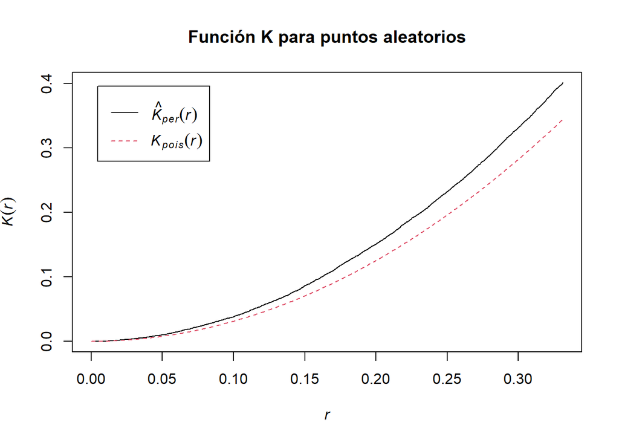

```r
# Trasformar objeto sf en ppp
ventana_aleatorios <- as.owin(st_bbox(aleatorios))
coords <- st_coordinates(aleatorios)
aleatorios_ppp <- ppp(x = coords[, 1], y = coords[, 2], window = ventana_aleatorios)

# Aplicar función para estimar la función de segundo momento reducida de Ripley
KAleatorio <- Kest(aleatorios_ppp, correction = 'periodic', var.approx = T)

plot(KAleatorio, main="Función K para puntos aleatorios")
```

“Agrupados”:

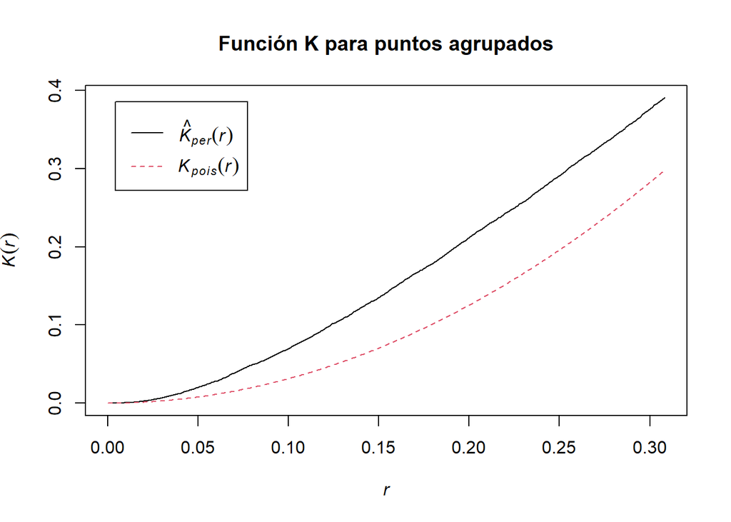

```r
# Trasformar objeto sf en ppp
ventana_agrupados <- as.owin(st_bbox(agrupados))
coords <- st_coordinates(agrupados)
agrupados_ppp <- ppp(x = coords[, 1], y = coords[, 2], window = ventana_agrupados)

# Aplicar función para estimar la función de segundo momento reducida de Ripley
KAgrupados <- Kest(agrupados_ppp, correction = 'periodic', var.approx = T)

plot(KAgrupados, main="Función K para puntos agrupados")
```

Regulares:

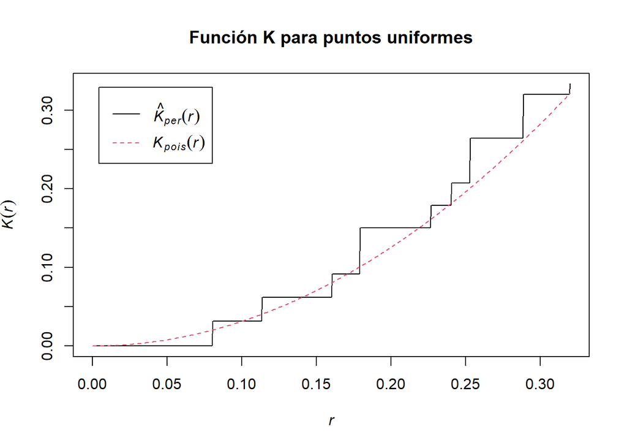

```r
# Trasformar objeto sf en ppp
ventana_uniforme <- as.owin(st_bbox(uniforme))
coords <- st_coordinates(uniforme)
uniforme_ppp <- ppp(x = coords[, 1], y = coords[, 2], window = ventana_uniforme)

# Aplicar función para estimar la función de segundo momento reducida de Ripley
KUniforme <- Kest(uniforme_ppp, correction = 'periodic', var.approx = T)

plot(KUniforme, main="Función K para puntos uniformes")
```

### 4) L(r)

Podemos generar una correción para facilitar la compara el `K` obtenido (
$$Kˆ(t)$$
) con el $K$ estadisticamente esperado ($K(t)$), con lo que llamamos la función `L` ($L(t)$).

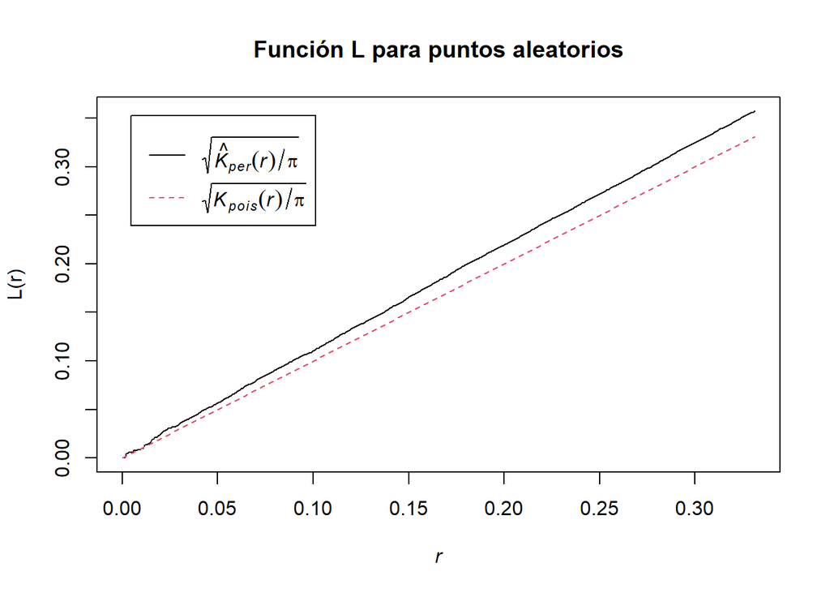

```r
LAleatorio <- sqrt(KAleatorio/pi)
plot(LAleatorio, ylab="L(r)", main="Función L para puntos aleatorios")
```

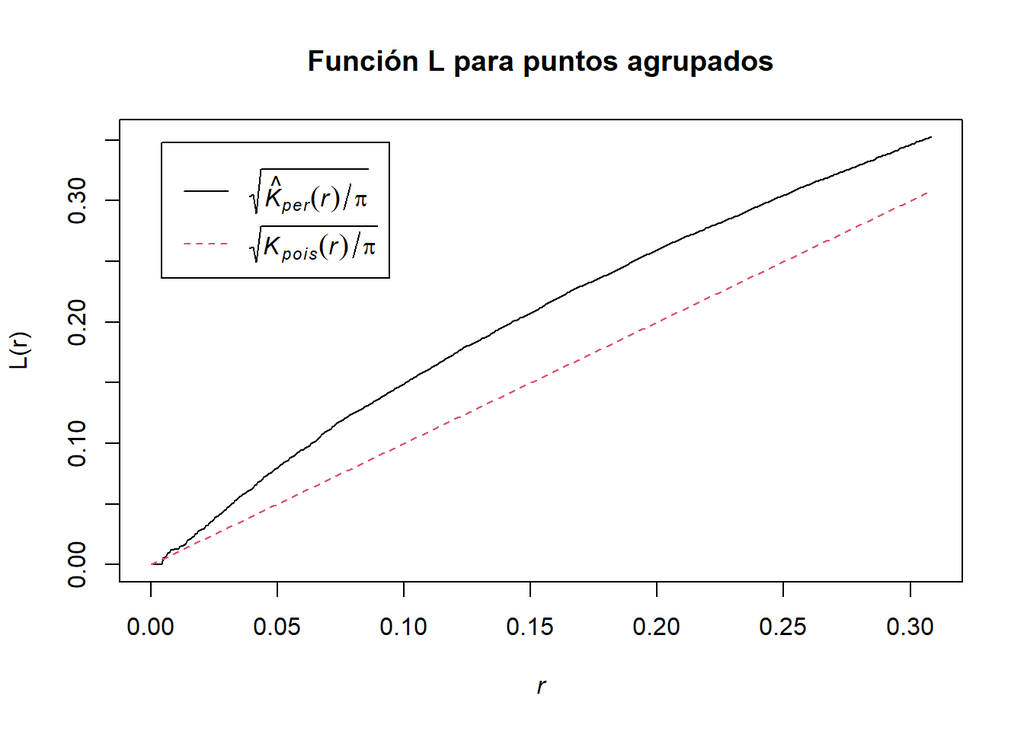

```r
LAgrupados <- sqrt(KAgrupados/pi)
plot(LAgrupados, ylab="L(r)", main="Función L para puntos agrupados")
```

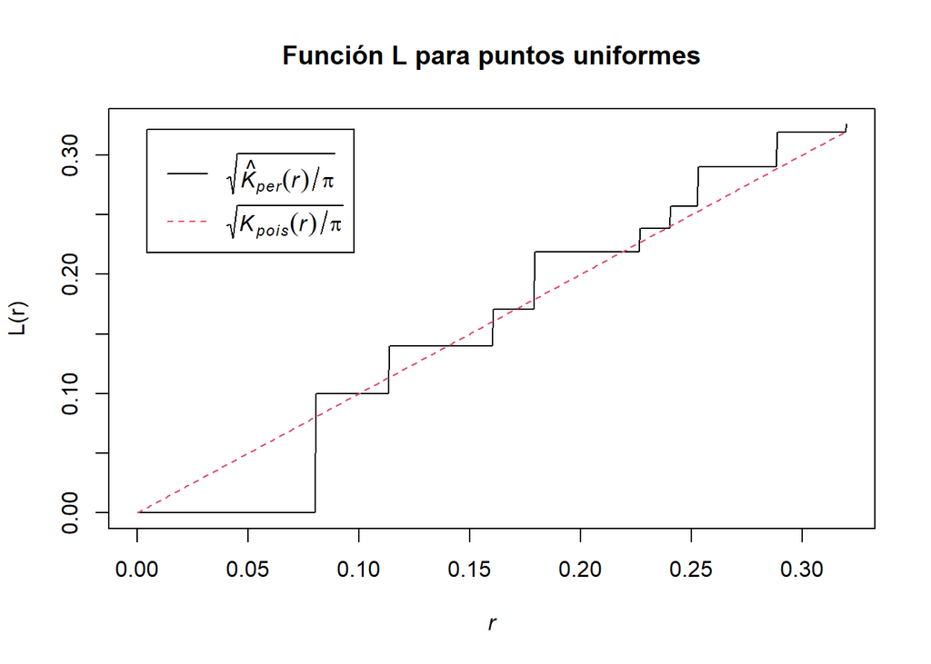

```r
LUniformes <- sqrt(KUniforme/pi)
plot(LUniformes, ylab="L(r)", main="Función L para puntos uniformes")
```

Con ggplot

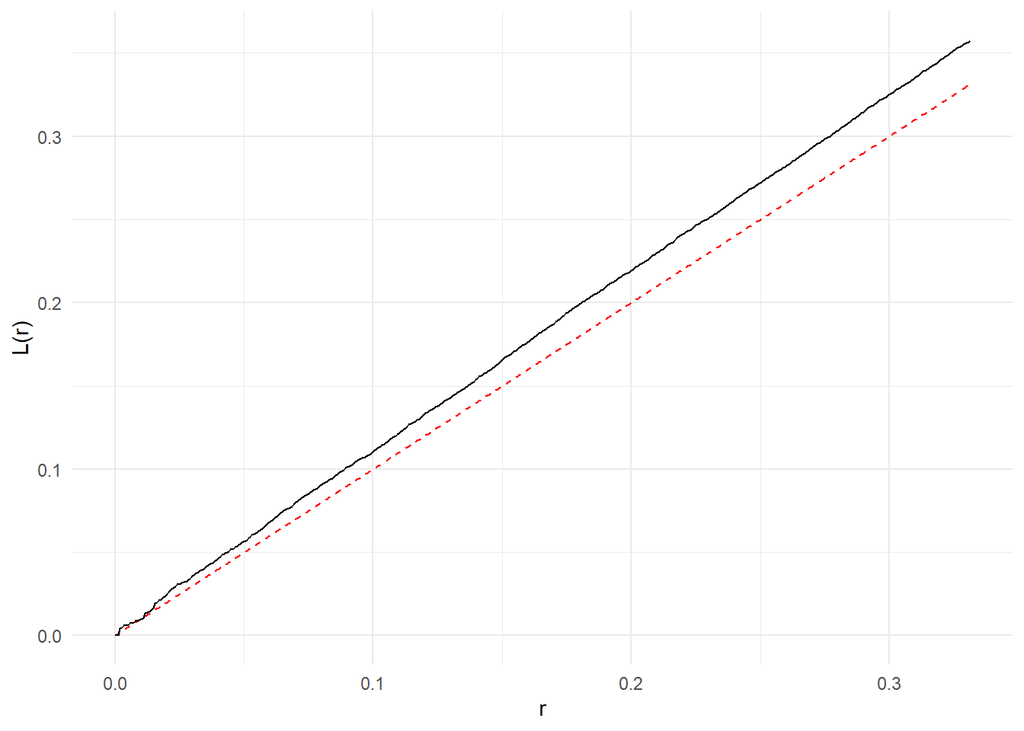

```r
LAleatorio_df <- data.frame(r = LAleatorio$r,
                            per = LAleatorio$per,
                            theo = LAleatorio$theo)

ggplot(LAleatorio_df) +
  geom_line(aes(r, theo), color = 'red', linetype = 'dashed') +
  geom_line(aes(r, per)) +
  labs(y = 'L(r)') +
  theme_minimal()
```

# Parte 2: Autocorrelograma

```r
# Borrar todo excepto las capas
rm(list = setdiff(ls(), c('agrupados', 'aleatorios', 'uniforme', 'losRios', 'arcilla')))
```

Hasta el momento, solo generamos un análisis con la posición espacial de los puntos, pero esta vez queremos ver cómo se aplica la ley de Tobler a través de un autocorrelograma. Para esto, necesitamos valores, los cuales extraeremos de una capa de contenido de arcilla para la región de Los Ríos a una profundidad de 5 a 15 cm.

```r
# ver raster
leaflet() %>%
  addRasterImage(arcilla, colors = "Greens") %>%
  addCircleMarkers(data = aleatorios, color = 'red', radius = 0.5, opacity = 1)
```

[interactive chart not shown]

```r
# extraer valores del raster
valores <- terra::extract(arcilla, aleatorios)
# agregar esos valores a la capa de puntos
aleatorios <- aleatorios %>%
  mutate(porcentajeArcilla = valores$Arcilla5_15LosRios) %>%
  filter(!is.na(porcentajeArcilla))

# pasar a UTM para hacer los calculos en metros
aleatorios <- st_transform(aleatorios, crs = 32718)
```

## Moran I

En el caso de la autocorrelación espacial indexada por el I de Moran, nos interesa el grado en que los valores de dos ubicaciones dentro de una cierta distancia (d) covarían.

Calculamos la autocovarianza espacial como la suma de los productos de las desviaciones de cada par de puntos, respecto a la media global obtenida en todo el paisaje para esa variable. See puede pensar como un tipo de covarianza estandarizada.

Si hacemos este analisis para distintas distancias podemos tener una intuición de a que distancia se pierde la correlación espacial (análisis de sensibilidad).

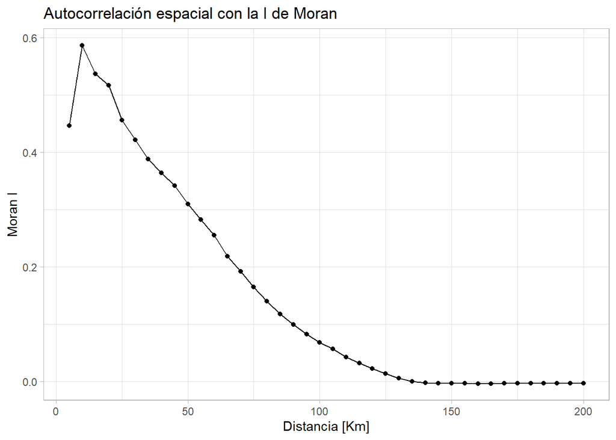

```r
# vector vacio donde se guardara el resultado del loop
moran_I <- c()

# for loop para calcular Moran I cambiando la distancia.
for (d in (seq(5, 200, 5)*1000)) {
  # Paso 1: Crear matriz de pesos espaciales
  aleatorios.nb <- dnearneigh(aleatorios, d1 = 0, d2 = d)
  aleatorios.lw <- nb2listw(aleatorios.nb, style = "W", zero.policy = TRUE)
  # Paso 2: Calcular el índice de Moran I
  moran <- moran.mc(aleatorios$porcentajeArcilla, aleatorios.lw, nsim = 100, zero.policy = TRUE)
  moran_I <- c(moran_I, moran$statistic)
}

# Generar df con el vector del loop
moran_I <- data.frame(moran = moran_I,
                      distance = (seq(5, 200, 5)*1000))

# Graficar
ggplot(moran_I, aes(x = distance/1000, y = moran)) +
  geom_point() +
  geom_line() +
  labs(x = 'Distancia [Km]',
       y = 'Moran I',
       title = 'Autocorrelación espacial con la I de Moran') +
  theme_light()
```

```r
# hecho en base a: https://pages.cms.hu-berlin.de/EOL/gcg_quantitative-methods/Lab15_SpatialRegression.html
```

## Correlograma con Spline

Existen otras maneras de evaluar la autocorrelación espacial, una de ellas es hacer un ‘spline correlogram’. El cual se basa en usar un spline de suavización para estimar la relación continua entre la distancia y los valores. A diferencia de otros metodos como Moran I, en donde los intervalos de distancia son discretos.

```r
aleatorios_sample <- aleatorios #%>% sample_n(100)

corrds <- st_coordinates(aleatorios_sample)
spline_corr <- spline.correlog(x = corrds[,1],
                               y = corrds[,2],
                               z = aleatorios_sample$porcentajeArcilla,
                               df = 15)
```

```
## 100  of  1000 200  of  1000 300  of  1000 400  of  1000 500  of  1000 600  of  1000 700  of  1000 800  of  1000 900  of  1000 1000  of  1000
```

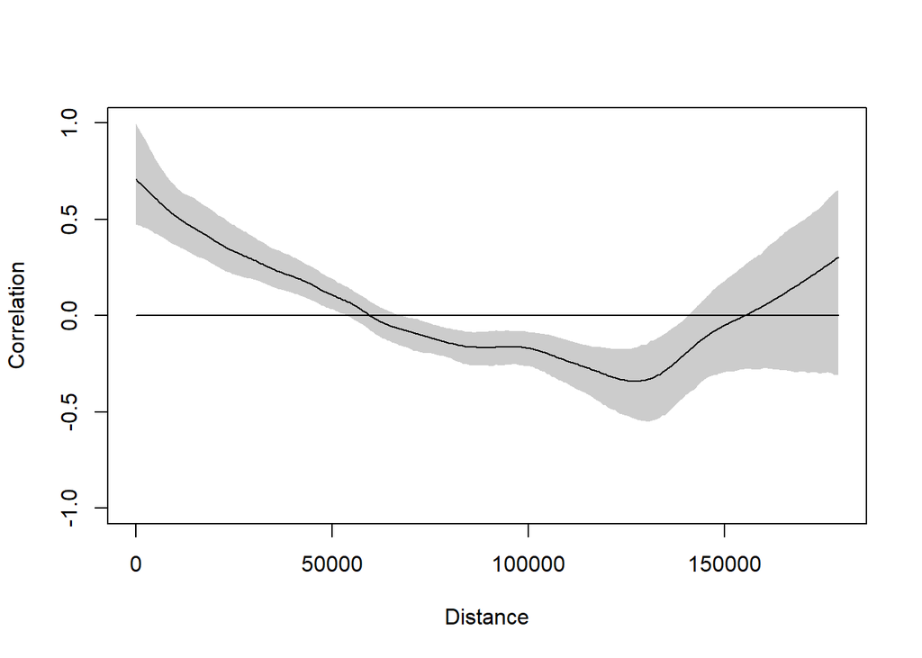

```r
plot(spline_corr)
```

# Parte 3: Semivariograma

El semivariograma es una herramienta ocupada para ver como cambia la variabilidad espacial con la distancia. Y se calcula mediante la mitad de la diferencia cuadrática media (*varianza*) entre puntos separados por una distancia $h$.

$$\gamma(h)=\frac{1}{2N_h}
\sum_{i=1}^{N_h}[ Z(x_i+h)-Z(x_i) ]^2$$

El gráfico que plotea el valor de la semivarianza ($\gamma$) a distintas distancias ($h$) es el **semivariograma**. Este tiene 3 elementos importantes para comprender la dependencia espacial de la cantidad evaluada.

- **Nugget**: (también llamado *efecto pepita* o *error de muestreo*) es el error de muestro. Correponde al valor de la semivarianza cuando $h = 0$ (es decir, en la intersección con el eje *y*). Aunque en teoría debería ser cero, la intersección suele ser mayor que cero en la práctica, debido a la presencia de heterogeneidad de microescala que no hemos medido (nuestra granularidad de muestreo es demasiado grande) o debido al muestreo o errores de medición resultantes de diferencias entre observadores (sesgo del observador), errores de instrumentación, etc. (Fortin y Dale, 2005).
- **Rango**: es la distancia ($h$) donde la semivarianza ($\gamma$) se estabiliza, o es máxima. En la práctica, el rango tiene unidades de distancia. Teóricamente indica el el punto desde el cuál deja de existir dependencia espacial para la variable estudiada y debiera (teóricamente) corresponder a la distance en que la autorrelación es cero (0). El rango se identifica por el punto donde los valores de $\gamma$ comienzan a estabilizarse (es decir, cuando $h \rightarrow$ “*Sill*”).
- **Sill**: La *varianza máxima/total*, o Sill, es un valor de $\gamma$ (medido en las unidades de la variable estudiada), y se refiere a la parte del variograma donde la semivarianza se estabiliza y forma una meseta. En este dominio, la distancia ya no afecta la estructura espacial de los datos (es decir, los datos son espacialmente independientes). Sin embargo, no todos los patrones espaciales tienen un Sill, o umbral de dependencia espacial!. Como la *varianza total* tiene unidades de la variable estudiada, al igual que el nugget, es posible descomponer el Sill en 2 partes, el Nugget y el *sill parcial*, que corresponde a la fracción de la varianza total menos la varianza que le corresponde al nugget. Asi *varianza total = error de muestreo + sill parcial*.

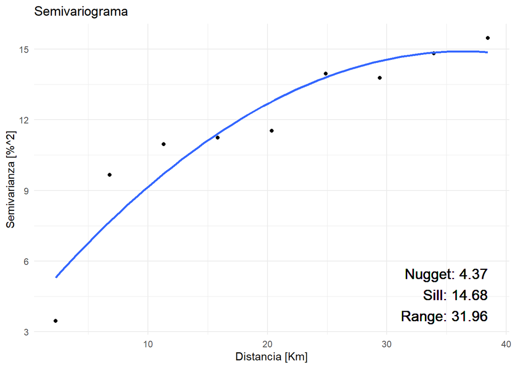

```r
aleatorios_sv <- geostats::semivariogram(x = corrds[,1],
              y = corrds[,2],
              z = aleatorios_sample$porcentajeArcilla,
              plot = F,
              nb = 9,
              )

aleatorios_sv_df <- tibble(dist_km = aleatorios_sv$h/1000,
                           sv = aleatorios_sv$sv)

ggplot(aleatorios_sv_df, aes(x = dist_km, y = sv)) +
  geom_point() +
  geom_smooth(method= 'lm', formula = 'y ~ poly(x, 2)', se = F) +
  geom_text(aes(x = max(dist_km), y = min(sv)),
            label = paste0('Nugget: ', aleatorios_sv$snr[2] %>% round(2),
                           '\nSill: ', aleatorios_sv$snr[1] %>% round(2),
                           '\nRange: ', (aleatorios_sv$snr[3]/1000) %>% round(2)),
            hjust = 1, vjust = 0,
            size = 5) +
  labs(x = 'Distancia [Km]',
       y = 'Semivarianza [%^2]',
       title = 'Semivariograma') +
  theme_minimal()
```

# Materia Opcional (fuera de los objetivos del curso)

Sin embargo, al realizar este calculo lo estamos haciendo sin considerar la direción de la distancia. Ante esto podemos generar un variograma de mapa para identidicar una posible direccionalidad en la fuerza de la dependencia espacial (Anisotropia).

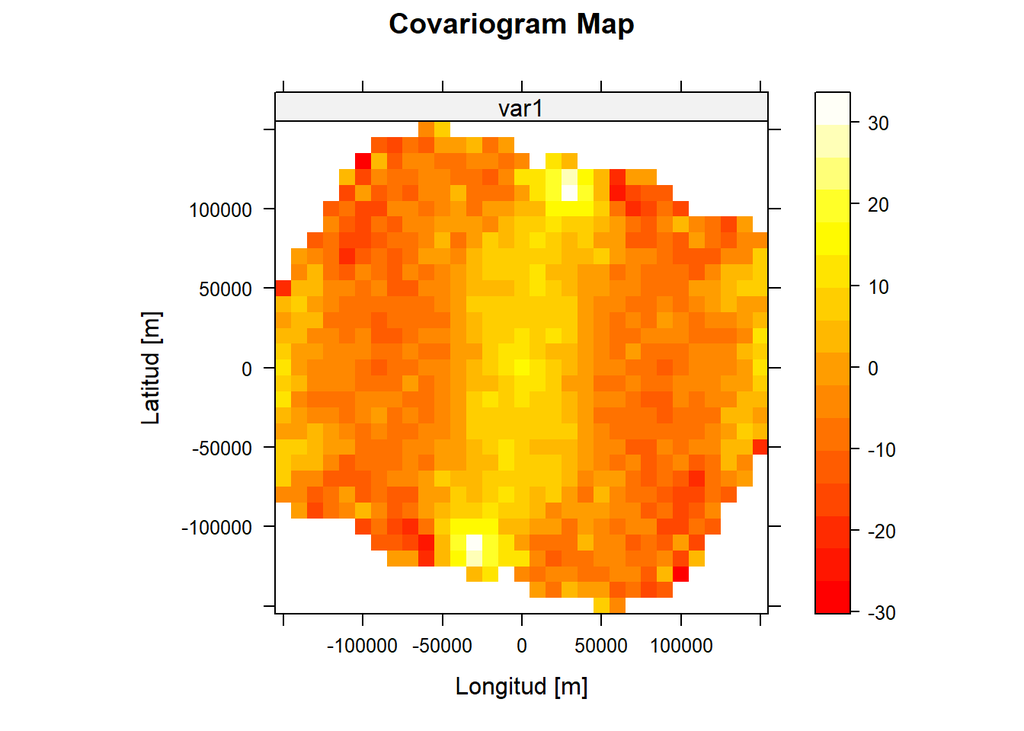

```r
# Calcular mapa de variograma
aleatorios_sv_map <- variogram(porcentajeArcilla ~ 1, aleatorios_sample,
                               map = TRUE, covariogram = T,
                               cutoff=150*1000, width=150/15*1000)
# graficar
plot(aleatorios_sv_map, col.regions = heat.colors(64),
     main="Covariogram Map",
     xlab="Longitud [m]",
     ylab="Latitud [m]")
```

Si tenemos una asimetria en la fuerza de la dependencia espacial podemos generar variogramas direccionales.

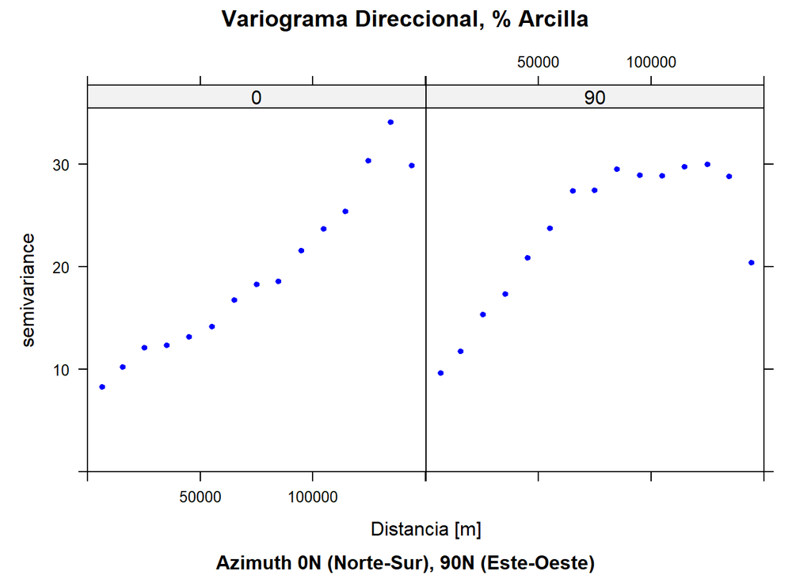

```r
plot(variogram(porcentajeArcilla ~ 1, aleatorios_sample,
               alpha = c(0, 90),
               cutoff = 150*1000,
               width=150/15*1000),
               main = "Variograma Direccional, % Arcilla",
               sub = "Azimuth 0N (Norte-Sur), 90N (Este-Oeste)",
               xlab="Distancia [m]",
               pch = 20, col = "blue")
```

# Tarea – grupos de no mas de 3 estudiantes

(Será presentada en clases)

1. Calcule el K de Ripley, haga un autocorrelograma con spline y realice un semivariograma, eligiendo para esto una de las capas de puntos y un ráster de la sección tarea.
2. Investiga cuál es la diferencia entre el semivariograma empírico y el modelado. Prepara una mini presentación con 2 semivariograma modelos como ejemplo.
3. Adicionalmente, sin el uso de mapas, y en base a los análisis anteriores, describa cómo se distribuyen los puntos a distintas escalas y en qué punto (unidades de distancia), aproximadamente se pierde la autocorrelación espacial.